# Exploratory Data Analysis (EDA)

GWU Intro to Data Science – DATS 6101

2024-09-12

## Data

Like before, let’s load our data and create a dataframe call **mlb**, then take a look.

```r
# getwd()
mlb <- read.csv("BaseballHeightWeight.csv", header = TRUE)
str(mlb)
```

```
## 'data.frame':    1034 obs. of  6 variables:
##  $ Name          : chr  "Adam_Donachie" "Paul_Bako" "Ramon_Hernandez" "Kevin_Millar" ...
##  $ Team          : chr  "BAL" "BAL" "BAL" "BAL" ...
##  $ Position      : chr  "Catcher" "Catcher" "Catcher" "First_Baseman" ...
##  $ Height.inches.: int  74 74 72 72 73 69 69 71 76 71 ...
##  $ Weight.pounds.: int  180 215 210 210 188 176 209 200 231 180 ...
##  $ Age           : num  23 34.7 30.8 35.4 35.7 ...
```

```r
head(mlb)
```

```
##              Name Team       Position Height.inches. Weight.pounds.  Age
## 1   Adam_Donachie  BAL        Catcher             74            180 23.0
## 2       Paul_Bako  BAL        Catcher             74            215 34.7
## 3 Ramon_Hernandez  BAL        Catcher             72            210 30.8
## 4    Kevin_Millar  BAL  First_Baseman             72            210 35.4
## 5     Chris_Gomez  BAL  First_Baseman             73            188 35.7
## 6   Brian_Roberts  BAL Second_Baseman             69            176 29.4
```

```r
# Changing variable names (HW #3)
colnames(mlb)[4:6]=c("height","weight","age")
# The line above produces no output. To see the changes, use str() or head()
xkabledplyhead(mlb, title = "Header rows for mlb dataset")
```

Header rows for mlb dataset

| Name | Team | Position | height | weight | age |
| --- | --- | --- | --- | --- | --- |
| Adam_Donachie | BAL | Catcher | 74 | 180 | 23.0 |
| Paul_Bako | BAL | Catcher | 74 | 215 | 34.7 |
| Ramon_Hernandez | BAL | Catcher | 72 | 210 | 30.8 |
| Kevin_Millar | BAL | First_Baseman | 72 | 210 | 35.4 |
| Chris_Gomez | BAL | First_Baseman | 73 | 188 | 35.7 |

## EDA Plots

Now, let’s do some EDA.

First, the histograms.

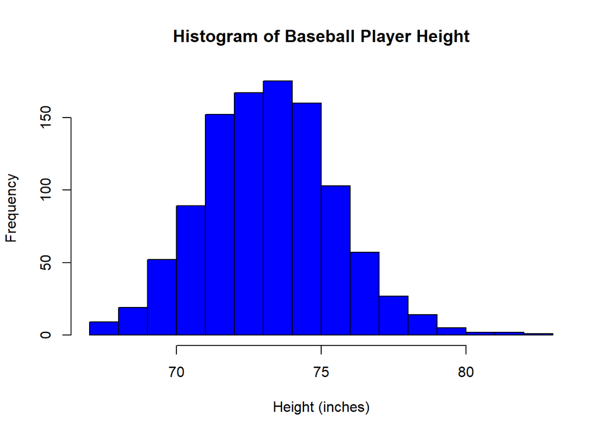

```r
# Start with individual variables, e.g. height.
hist(mlb$height, main="Histogram of Baseball Player Height", xlab="Height (inches)", col = 'blue' )
```

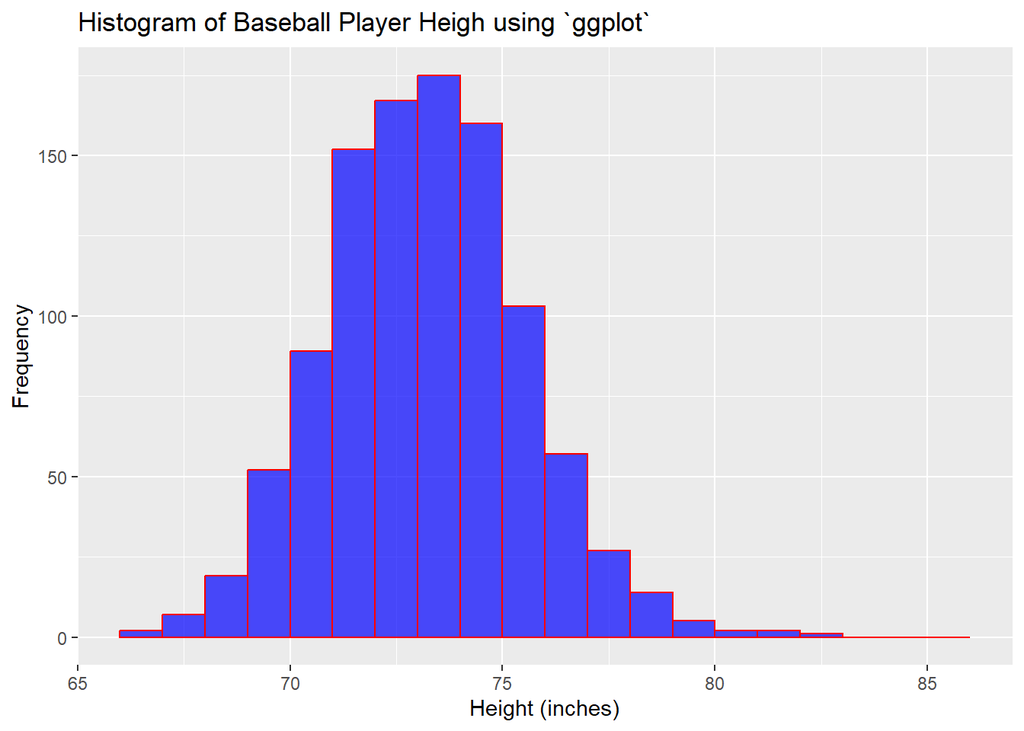

```r
library(ggplot2)
ggplot(data=mlb, aes(height)) +
  geom_histogram(breaks=seq(66, 86, by = 1),
                 col="red",
                 fill="blue",
                 alpha = .7) + # opacity
  labs(x="Height (inches)", y="Frequency") +
  labs(title="Histogram of Baseball Player Heigh using `ggplot`")
```

Next try the boxplots.

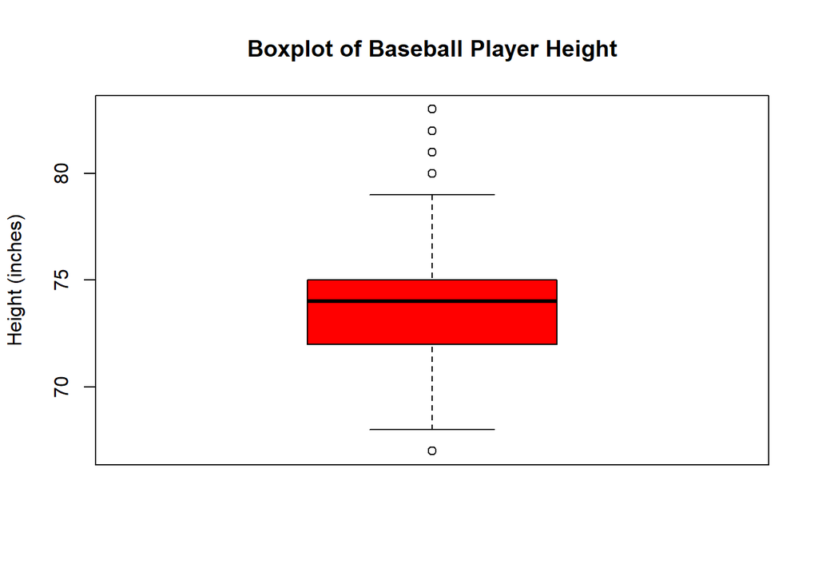

```r
boxplot(mlb$height, main="Boxplot of Baseball Player Height", ylab="Height (inches)", col = 'red' )
```

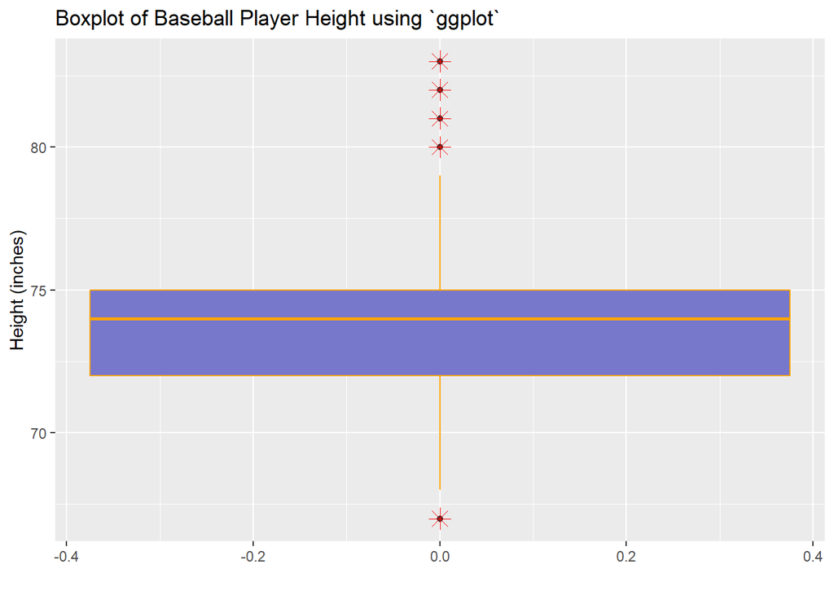

```r
ggplot(mlb, aes(y=height)) +
  geom_boxplot() +
  geom_boxplot( colour="orange", fill="#7777cc", outlier.colour="red", outlier.shape=8, outlier.size=4) +
  labs(title="Boxplot of Baseball Player Height using `ggplot`", x="", y = "Height (inches)")
```

Now the Q-Q plot, adding a theoretical line to the plot.

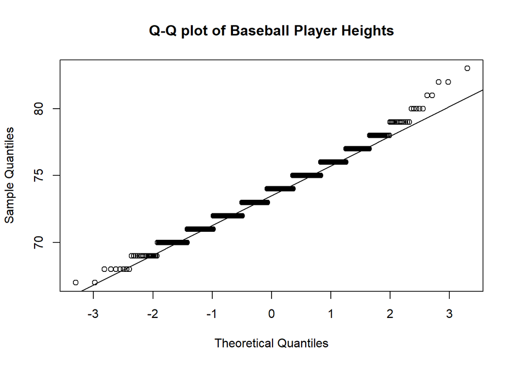

```r
qqnorm(mlb$height, main="Q-Q plot of Baseball Player Heights")
qqline(mlb$height)
```

```r
shapiro.test(mlb$height) # Shapiro-Wilk test for normality
```

```
##
##  Shapiro-Wilk normality test
##
## data:  mlb$height
## W = 1, p-value = 2e-10
```

```r
ks.test(mlb$height,pnorm) # Kolmogorov-Smirnov Tests against normal distribution
```

```
##
##  Asymptotic one-sample Kolmogorov-Smirnov test
##
## data:  mlb$height
## D = 1, p-value <2e-16
## alternative hypothesis: two-sided
```

We’ll talk more about the shapiro test after we introduce formal statistical testings. In the meantime, we can look into other EDA tools and techniques.

## Summary Statistics: Mean, Variance

```r
sd.height <- sd(mlb$height)
mean.height <- mean(mlb$height)
# sd.weight <- sd(mlb$weight)   # error if there are N/A values
sd.weight <- sd(mlb$weight, na.rm = TRUE)
mean.weight <- mean(mlb$weight, na.rm = TRUE)
mean.weight
```

```
## [1] 202
```

```r
sd.weight
```

```
## [1] 21
```

```r
sd.height
```

```
## [1] 2.31
```

We can also run the variance, mean, and sd directly.

```r
var(mlb$height, na.rm = T)
```

```
## [1] 5.32
```

```r
mean(mlb$height, na.rm = T)
```

```
## [1] 73.7
```

```r
sd(mlb$height, na.rm = T)
```

```
## [1] 2.31
```

## Unusual Observations: A Handy Outlier Function

This function will show you a quick view of the data with and without the outliers. You need to choose to option of whether you want to remove the outliers at the end of execution. You can also modify the codes per your need, such as no prompt for easier knitting, or option to remove the outlier and save as a different dataframe. I have included this outlierKD function (by Klodian Dhana) into the `ezids` library for convenience. The following code chunk is NOT evaluated. The one in `ezids` will be loaded and used instead.

```r
# By Klodian Dhana, https://www.r-bloggers.com/identify-describe-plot-and-remove-the-outliers-from-the-dataset/
# I have also included this outlierKD function in the `ezids` library.
# There is no need in the future to copy/paste this function as long as the ezids library has been loaded.
# I have also included a modified version outlierKD2( ) function in the `ezids` library to tweak it for our needs.
#
outlierKD <- function(dt, var) {
     var_name <- eval(substitute(var),eval(dt))
     na1 <- sum(is.na(var_name))
     m1 <- mean(var_name, na.rm = T)
     par(mfrow=c(2, 2), oma=c(0,0,3,0))
     boxplot(var_name, main="With outliers")
     hist(var_name, main="With outliers", xlab=NA, ylab=NA)
     outlier <- boxplot.stats(var_name)$out
     mo <- mean(outlier)
     var_name <- ifelse(var_name %in% outlier, NA, var_name)
     boxplot(var_name, main="Without outliers")
     hist(var_name, main="Without outliers", xlab=NA, ylab=NA)
     title("Outlier Check", outer=TRUE)
     na2 <- sum(is.na(var_name))
     cat("Outliers identified:", na2 - na1, "n")
     cat("Propotion (%) of outliers:", round((na2 - na1) / sum(!is.na(var_name))*100, 1), "n")
     cat("Mean of the outliers:", round(mo, 2), "n")
     m2 <- mean(var_name, na.rm = T)
     cat("Mean without removing outliers:", round(m1, 2), "n")
     cat("Mean if we remove outliers:", round(m2, 2), "n")
     response <- readline(prompt="Do you want to remove outliers and to replace with NA? [yes/no]: ")
     if(response == "y" | response == "yes"){
          dt[as.character(substitute(var))] <- invisible(var_name)
          assign(as.character(as.list(match.call())$dt), dt, envir = .GlobalEnv)
          cat("Outliers successfully removed", "n")
          return(invisible(dt))
     } else{
          cat("Nothing changed", "n")
          return(invisible(var_name))
     }
}
```

Running the outlierKD code below triggers a prompt on the console window (yes/no). Answer there to continue.

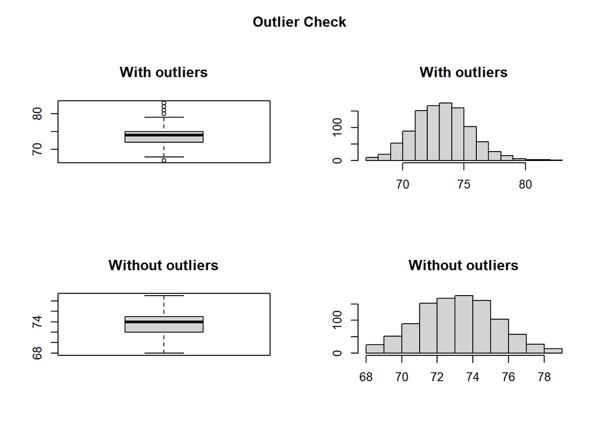

```
## Outliers identified: 12
## Proportion (%) of outliers: 1.2
## Mean of the outliers: 78.6
## Mean without removing outliers: 73.7
## Mean if we remove outliers: 73.6
## Do you want to remove outliers and to replace with NA? [yes/no]:
## Nothing changed
```

```r
outlierKD(mlb, height)
```

Now you can check if the dataframe is changed.

```r
str(mlb)
```

```
## 'data.frame':    1034 obs. of  6 variables:
##  $ Name    : chr  "Adam_Donachie" "Paul_Bako" "Ramon_Hernandez" "Kevin_Millar" ...
##  $ Team    : chr  "BAL" "BAL" "BAL" "BAL" ...
##  $ Position: chr  "Catcher" "Catcher" "Catcher" "First_Baseman" ...
##  $ height  : int  74 74 72 72 73 69 69 71 76 71 ...
##  $ weight  : int  180 215 210 210 188 176 209 200 231 180 ...
##  $ age     : num  23 34.7 30.8 35.4 35.7 ...
```

```r
summary(mlb)
```

```
##      Name               Team             Position             height
##  Length:1034        Length:1034        Length:1034        Min.   :67.0
##  Class :character   Class :character   Class :character   1st Qu.:72.0
##  Mode  :character   Mode  :character   Mode  :character   Median :74.0
##                                                           Mean   :73.7
##                                                           3rd Qu.:75.0
##                                                           Max.   :83.0
##
##      weight         age
##  Min.   :150   Min.   :20.9
##  1st Qu.:187   1st Qu.:25.4
##  Median :200   Median :27.9
##  Mean   :202   Mean   :28.7
##  3rd Qu.:215   3rd Qu.:31.2
##  Max.   :290   Max.   :48.5
##  NA's   :1
```

I took the outlierKD function and made some modifications. First, the user input propmt is built into the function (default: do not remove outlier). The new function also allow the returned result be saved as another dataframe, so that the original dataframe can be left intact. A QQ-plot option is also added. See help menu for more detailed documentation.

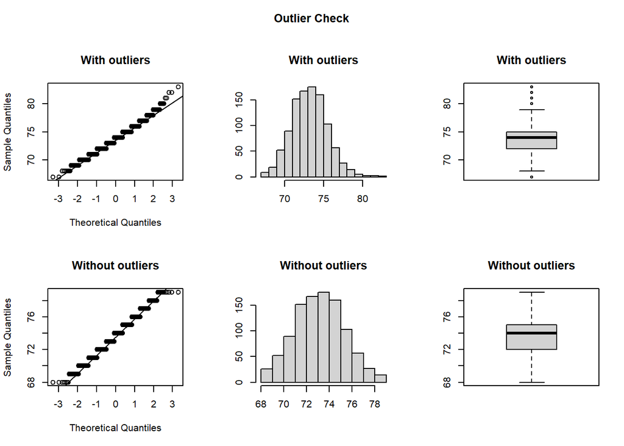

```
## Outliers identified: 12
## Proportion (%) of outliers: 1.2
## Mean of the outliers: 78.6
## Mean without removing outliers: 73.7
## Mean if we remove outliers: 73.6
## Outliers successfully removed
```

```r
mlbclean = outlierKD2(mlb, height, rm = TRUE, boxplt = TRUE, qqplt = TRUE)
```

Now check the new dataframe:

```r
str(mlbclean)
```

```
## 'data.frame':    1034 obs. of  6 variables:
##  $ Name    : chr  "Adam_Donachie" "Paul_Bako" "Ramon_Hernandez" "Kevin_Millar" ...
##  $ Team    : chr  "BAL" "BAL" "BAL" "BAL" ...
##  $ Position: chr  "Catcher" "Catcher" "Catcher" "First_Baseman" ...
##  $ height  : int  74 74 72 72 73 69 69 71 76 71 ...
##  $ weight  : int  180 215 210 210 188 176 209 200 231 180 ...
##  $ age     : num  23 34.7 30.8 35.4 35.7 ...
```

```r
summary(mlbclean)
```

```
##      Name               Team             Position             height
##  Length:1034        Length:1034        Length:1034        Min.   :68.0
##  Class :character   Class :character   Class :character   1st Qu.:72.0
##  Mode  :character   Mode  :character   Mode  :character   Median :74.0
##                                                           Mean   :73.6
##                                                           3rd Qu.:75.0
##                                                           Max.   :79.0
##                                                           NA's   :12
##      weight         age
##  Min.   :150   Min.   :20.9
##  1st Qu.:187   1st Qu.:25.4
##  Median :200   Median :27.9
##  Mean   :202   Mean   :28.7
##  3rd Qu.:215   3rd Qu.:31.2
##  Max.   :290   Max.   :48.5
##  NA's   :1
```

As you can see, the outliers are replaced by NAs. They are not deleted from the df.

## Z-Scores (A Preview)

Now that we know the mean and std we can generate a z score for individual heights and probabilities

```r
z80height <- (80-mean.height)/sd.height
z80height
```

```
## [1] 2.73
```

Note that now we have a z score, we could look it up on a table or use R to calculate the percentage (assumed normal dist), pnorm tells us the percentage.

[output not shown]

[output not shown]

Better yet, we can convert raw scores into z-scores easily for all the data:

```r
mlb$zheight = scale(mlb$height)
mlb$zweight = scale(mlb$weight)
```

Notice that the dataframe mlb has two more columns/variables now.

Let us simply check that zheight and zweight are centered at zero, with sd = 1 as expected.

```r
mean(mlb$zheight, na.rm = TRUE)
```

```
## [1] -4.61e-16
```

```r
sd(mlb$zheight, na.rm = TRUE)
```

```
## [1] 1
```

```r
summary(mlb$zheight)
```

```
##        V1
##  Min.   :-2.90
##  1st Qu.:-0.74
##  Median : 0.13
##  Mean   : 0.00
##  3rd Qu.: 0.56
##  Max.   : 4.03
```

```r
summary(mlb$zweight)
```

```
##        V1
##  Min.   :-2.46
##  1st Qu.:-0.70
##  Median :-0.08
##  Mean   : 0.00
##  3rd Qu.: 0.63
##  Max.   : 4.21
##  NA's   :1
```

And try this describe function:

```r
library("Hmisc") # this package contains the describe function below
describe(mlb$weight)
```

```
## mlb$weight
##        n  missing distinct     Info     Mean      Gmd      .05      .10
##     1033        1       89    0.996    201.7    23.57    170.0    175.2
##      .25      .50      .75      .90      .95
##    187.0    200.0    215.0    230.0    240.0
##
## lowest : 150 155 156 160 163, highest: 260 270 275 278 290
```

It’s a nicer way to describe the data, then say, `summary()`. But `describe()` does not work on the entire dataframe. Only one vector at a time.